# Amazon Fire Product Categories & Review Date/Time Part 1

Eugenie

30/10/2019

# 1 Load Source File

Data pre-processing is included, where special chars and minimal stop-words are removed.

```r
library(data.table)
## load review data
source("~/Dropbox/Eugenie/scripts/libs.R")
```

# 2 Time Data vs. Rating

## 2.1 Data processing

Split data on date without splitting incentivized vs. non-incentivized reviews after 2016-10-03.

```r
## split on date
reviews.product_non <- reviews.product[reviews.product$date<'2016-10-03'&reviews.product$incentivized=='non-incentivized',]
reviews.product_incentivized <- reviews.product[reviews.product$date<'2016-10-03'&reviews.product$incentivized=='incentivized',]
reviews.product_after <- reviews.product[reviews.product$date>'2016-10-03',]
```

Split data on date with split incentivized vs. non-incentivized reviews after 2016-10-03.

```r
## split on date
reviews.product_non1 <- reviews.product[reviews.product$date<'2016-10-03'&reviews.product$incentivized=='non-incentivized',]
reviews.product_incentivized1 <- reviews.product[reviews.product$date<'2016-10-03'&reviews.product$incentivized=='incentivized',]
reviews.product_non2 <- reviews.product[reviews.product$date>'2016-10-03'&reviews.product$incentivized=='non-incentivized',]
reviews.product_incentivized2 <- reviews.product[reviews.product$date>'2016-10-03'&reviews.product$incentivized=='incentivized',]
```

Compute rating stats without splitting incentivized vs. non-incentivized reviews after 2016-10-03.

```r
## mean rating by day
reviews.product_non <- reviews.product_non %>%
  group_by(brand.bi, date) %>%
  mutate(day_rating = mean(rating))

reviews.product_incentivized <- reviews.product_incentivized %>%
  group_by(brand.bi, date) %>%
  mutate(day_rating = mean(rating))

reviews.product_after <- reviews.product_after %>%
  group_by(brand.bi, date) %>%
  mutate(day_rating = mean(rating))

## mean rating by week
reviews.product_non <- reviews.product_non %>%
  group_by(brand.bi, year, week(date)) %>%
  mutate(week_rating = mean(rating))

reviews.product_incentivized <- reviews.product_incentivized %>%
  group_by(brand.bi, year, week(date)) %>%
  mutate(week_rating = mean(rating))

reviews.product_after <- reviews.product_after %>%
  group_by(brand.bi, year, week(date)) %>%
  mutate(week_rating = mean(rating))

## mean rating by month
reviews.product_non <- reviews.product_non %>%
  group_by(brand.bi, month) %>%
  mutate(month_rating = mean(rating))

reviews.product_incentivized <- reviews.product_incentivized %>%
  group_by(brand.bi, month) %>%
  mutate(month_rating = mean(rating))

reviews.product_after <- reviews.product_after %>%
  group_by(brand.bi, month) %>%
  mutate(month_rating = mean(rating))
```

Compute rating stats with split incentivized vs. non-incentivized reviews after 2016-10-03, using the same procedure as above.

## 2.2 Plot mean rating over time by brand.bi without splitting incentivized vs. non-incentivized reviews after 2016-10-03

Although there’re still reviews labelled as incentivized after 2016-10-03, since I’m not sure how that happened (e.g., prediction from ReviewMeta), I’m leaving it unsplit. The split version of the same analysis is in the next section.

### 2.2.1 Rating average by day

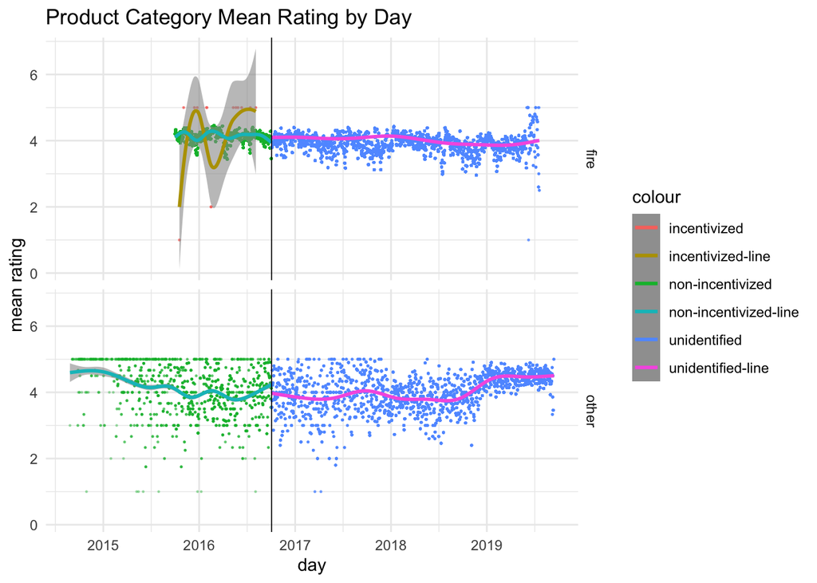

Observed that prior to 2016-10-03, the day average of incentivized reviews is generally higher and has a greater variation than non-incentivized reviews.

### 2.2.2 Rating averaged by week

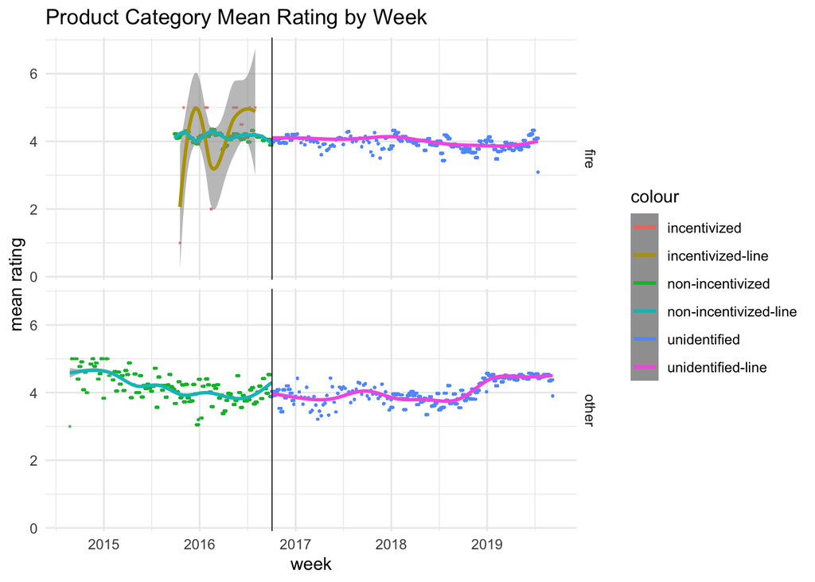

### 2.2.3 Rating averaged by month

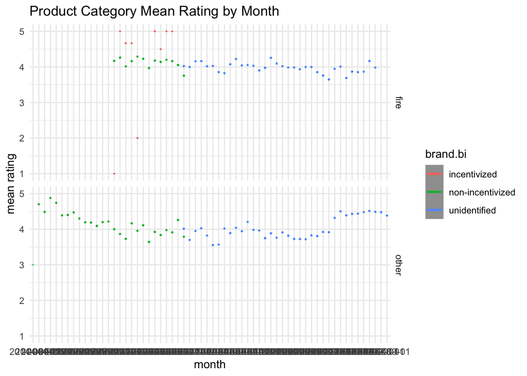

## 2.3 Plot mean rating over time by brand.bi with split incentivized vs. non-incentivized reviews after 2016-10-03

### 2.3.1 Rating average by day

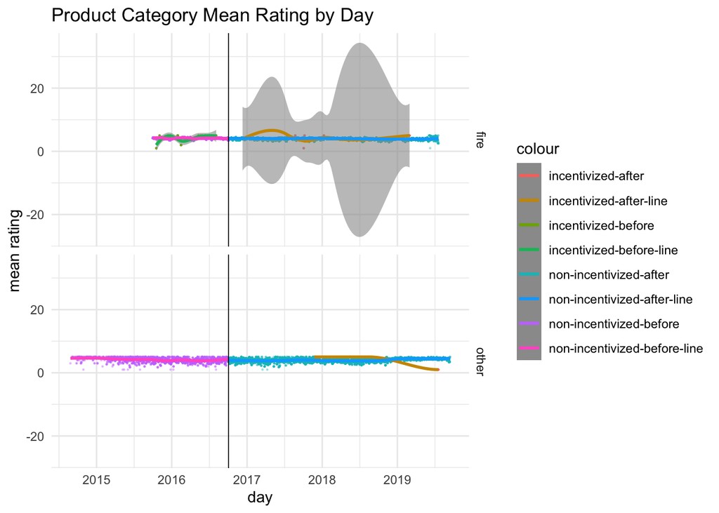

Noticed that due to the lack of data points (i.e., labelled incentivized reviews) after 2016-10-03, the lines are looking weird. I’m not sure if the result is meanful or not, so I’m dropping these for the analysis of word_count and helpful_yes.

### 2.3.2 Rating averaged by week

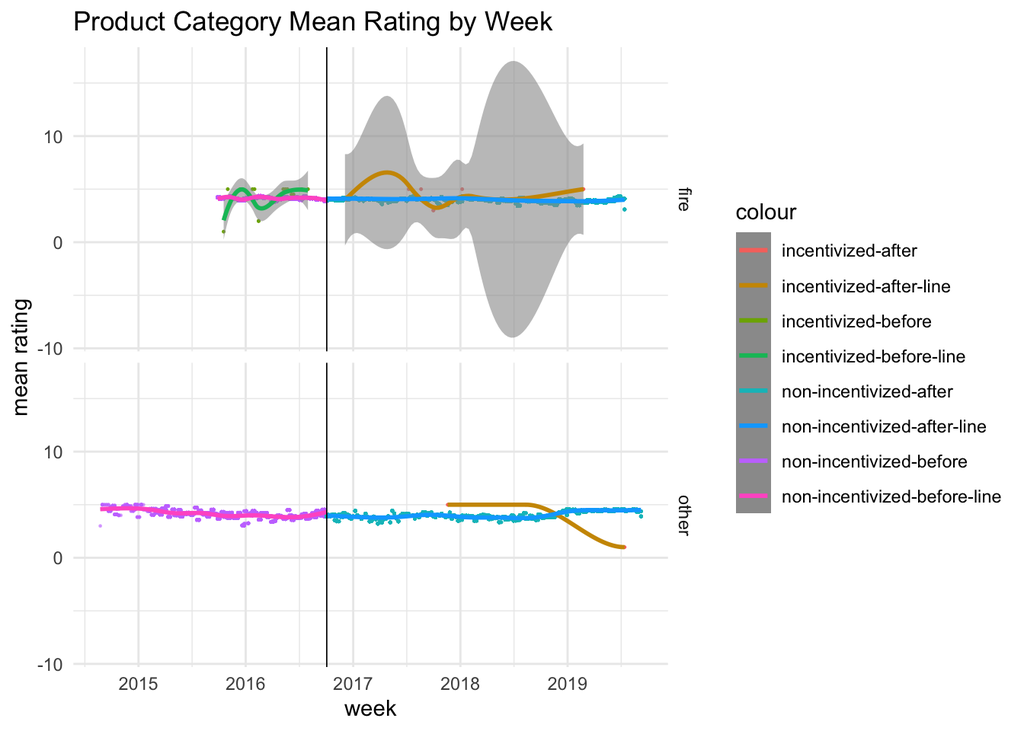

### 2.3.3 Rating averaged by month

Basically the same graph as the ‘rating average by week’.

# 3 Word Count

## 3.1 Data Processing

Compute word count stats with the same precudure as above.

## 3.2 Plot mean word_count over time by brand.bi

### 3.2.1 word_count average by day

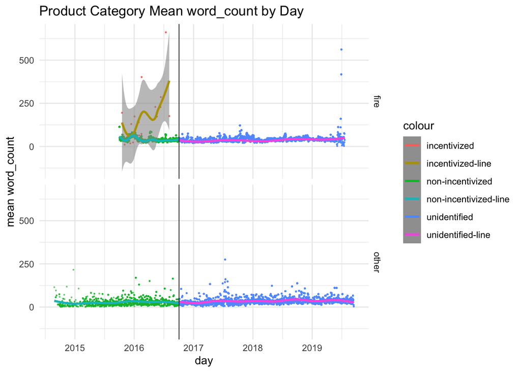

Same as the rating analysis, observed that prior to 2016-10-03, the daily word count average of incentivized reviews is higher and has a greater variation than non-incentivized reviews.

### 3.2.2 word_count averaged by week

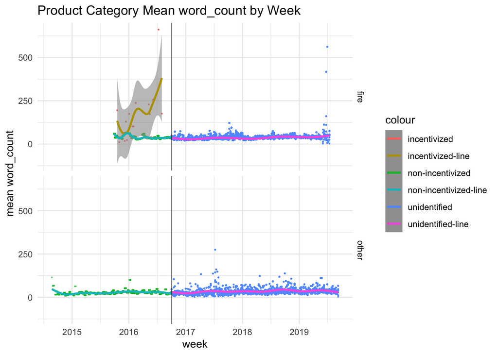

### 3.2.3 word_count averaged by month

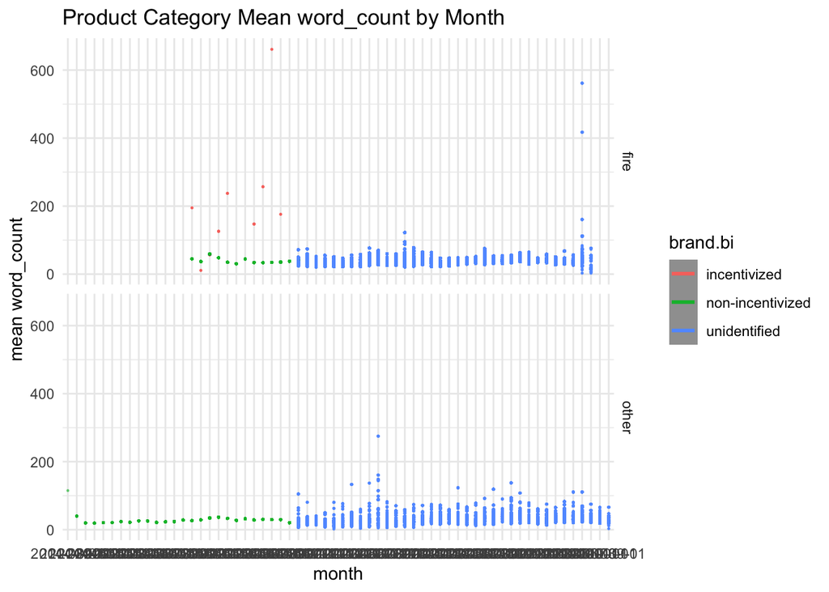

# 4 Helpful_yes

## 4.1 Data Processing

Compute helpful_yes stats with the same precudure as above.

## 4.2 General stats

```r
cat_sum <- reviews.product %>%
  mutate(is_after = ifelse(date > '2016-10-03','after 2016-10-03','before 2016-10-03')) %>%
  mutate(is_zero = ifelse(helpful_yes > 0,'greater than 0','0')) %>%
  group_by(is_after,is_zero) %>%
  summarise(review.count = n()) %>%
  mutate(review.pct = review.count/sum(review.count)*100)
cat_sum
```

```
## # A tibble: 3 x 4
## # Groups:   is_after [2]
##   is_after          is_zero        review.count review.pct
##   <chr>             <chr>                 <int>      <dbl>
## 1 after 2016-10-03  0                    226133     100
## 2 before 2016-10-03 0                     80208      98.8
## 3 before 2016-10-03 greater than 0          945       1.16
```

## 4.3 Plot mean helpful_yes over time by brand.bi

### 4.3.1 helpful_yes average by day

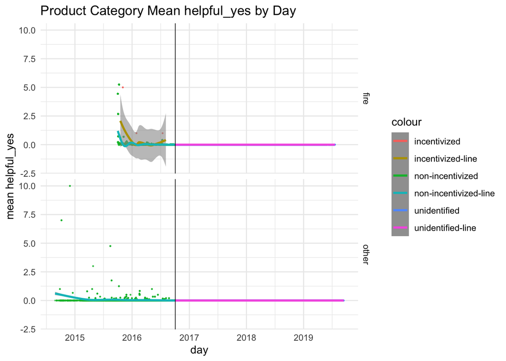

### 4.3.2 helpful_yes averaged by week

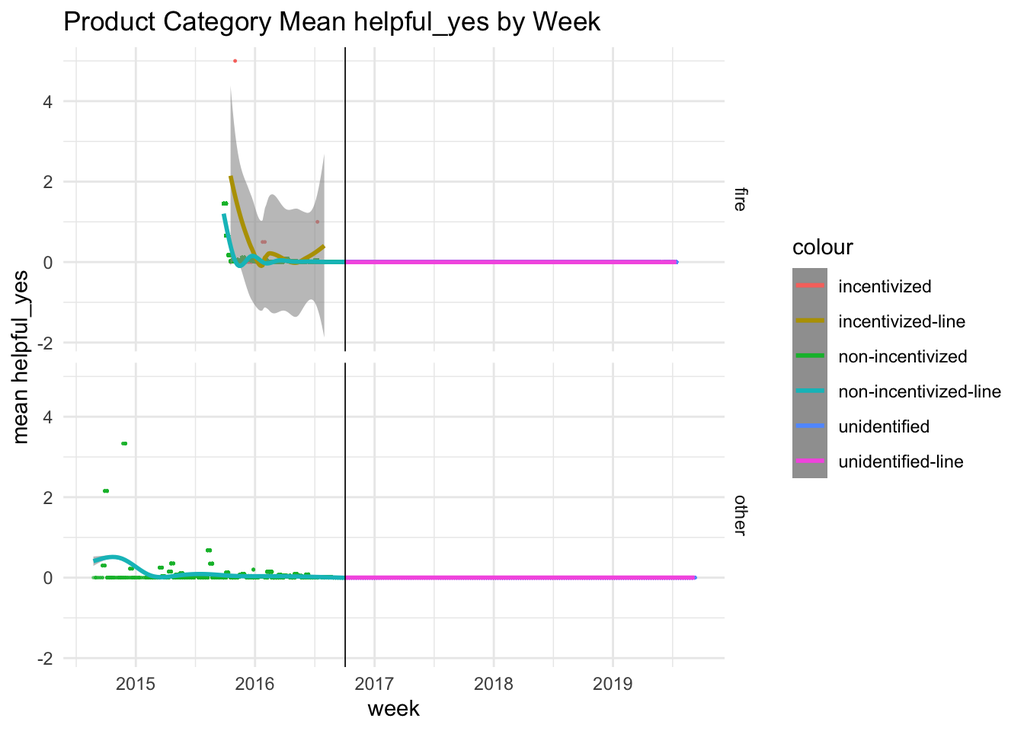

### 4.3.3 helpful_yes averaged by month

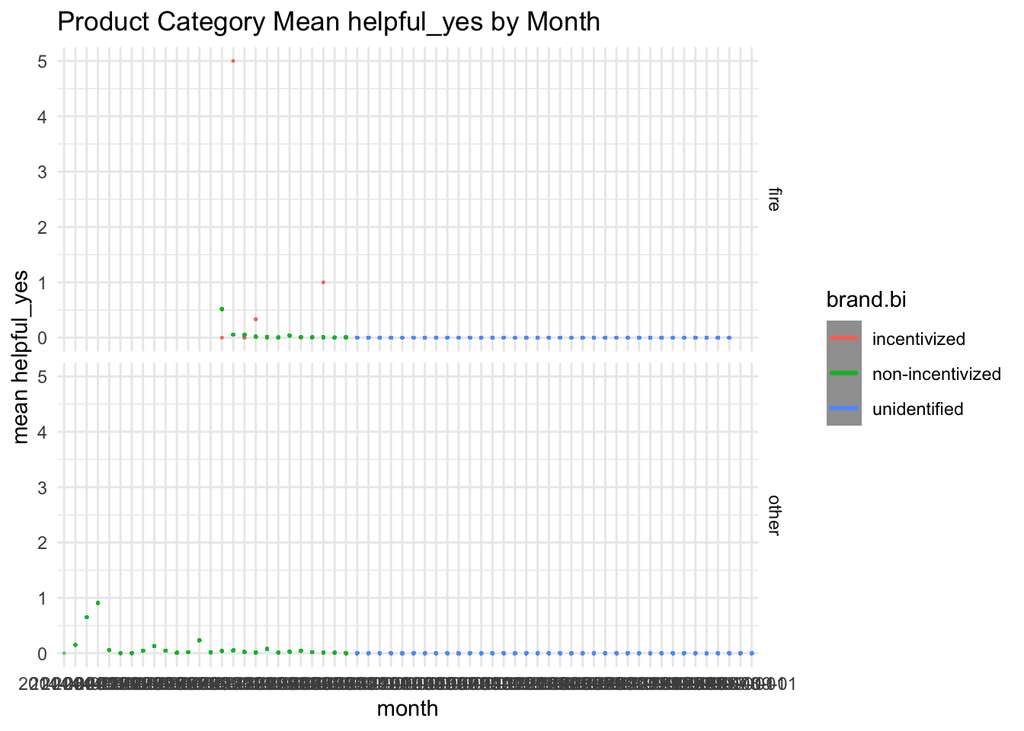